# Project Supervised Learning - Saravanan Janarthanan

## Part A

DOMAIN: Medical

• CONTEXT: Medical research university X is undergoing a deep research on patients with certain conditions. University has an internal AI team. Due to confidentiality the patient’s details and the conditions are masked by the client by providing different datasets to the AI team for developing a AIML model which can predict the condition of the patient depending on the received test results.

• DATA DESCRIPTION: The data consists of biomechanics features of the patients according to their current conditions. Each patient is represented in the data set by six biomechanics attributes derived from the shape and orientation of the condition to their body part.

**1. Data Understanding:**

**Q 1A . Read all the 3 CSV files as DataFrame and store them into 3 separate variables**

**Ans 1A** Use read_csv() function to load the data into three Data frames

```python
# Load libraries
import numpy  as np
import pandas as pd
import scipy.stats as stats
import matplotlib.pyplot as plt
import seaborn as sns

class color:
   BOLD = '\033[1m'
   END = '\033[0m'
```

```python
# Read the data files
# Load the Normal CSV data
part_1_Normal_data = pd.read_csv( 'SupervisedLearningProject\Part1_Normal.csv' )

# Load the Type H CSV data
part_1_Type_H_data = pd.read_csv( 'SupervisedLearningProject\Part1_Type_H.csv' )

# Load the Type S CSV data
part_1_Type_S_data = pd.read_csv( 'SupervisedLearningProject\Part1_Type_S.csv' )
```

**Q 1B Print Shape and columns of all the 3 DataFrames**

**Ans 1B** Use the shape function in Dataframe to print the details

```python
# Print the shape, rows and columns details of Normal Dataframe
Normal_DF_shape = part_1_Normal_data.shape
print(color.BOLD + 'Ans. 1B Normal CSV DataFrame Shape'+color.END)
print( '\nDataFrame Shape   :', Normal_DF_shape )
print( '\nNumber of rows    :', Normal_DF_shape[0] )
print( '\nNumber of columns :', Normal_DF_shape[1] )
```

```
Ans. 1B Normal CSV DataFrame Shape

DataFrame Shape   : (100, 7)

Number of rows    : 100

Number of columns : 7
```

```python
# Print the shape, rows and columns details of Type S  Dataframe
TypeS_DF_shape = part_1_Type_S_data.shape
print(color.BOLD +'Ans. 1B Type S CSV DataFrame Shape'+color.END)
print( '\nType S CSV DataFrame Shape :', TypeS_DF_shape )
print( '\nNumber of rows             :', TypeS_DF_shape[0] )
print( '\nNumber of columns          :', TypeS_DF_shape[1] )
```

```
Ans. 1B Type S CSV DataFrame Shape

Type S CSV DataFrame Shape : (150, 7)

Number of rows             : 150

Number of columns          : 7
```

```python
# Print the shape, rows and columns details of Type S  Dataframe
TypeH_DF_shape = part_1_Type_H_data.shape
print(color.BOLD +'Ans. 1B Type H CSV DataFrame Shape'+color.END)
print( '\nType H CSV DataFrame Shape :', TypeH_DF_shape )
print( '\nNumber of rows             :', TypeH_DF_shape[0] )
print( '\nNumber of columns          :', TypeH_DF_shape[1] )
```

```
Ans. 1B Type H CSV DataFrame Shape

Type H CSV DataFrame Shape : (60, 7)

Number of rows             : 60

Number of columns          : 7
```

**Q 1C Compare Column names of all the 3 DataFrames and clearly write observation**

**Ans 1C**

```python
# Print the top 5 rows data with column header info for Normal dataframe
part_1_Normal_data.head()
```

|  | P_incidence | P_tilt | L_angle | S_slope | P_radius | S_Degree | Class |
| --- | --- | --- | --- | --- | --- | --- | --- |
| 0 | 38.505273 | 16.964297 | 35.112814 | 21.540976 | 127.632875 | 7.986683 | Normal |
| 1 | 54.920858 | 18.968430 | 51.601455 | 35.952428 | 125.846646 | 2.001642 | Normal |
| 2 | 44.362490 | 8.945435 | 46.902096 | 35.417055 | 129.220682 | 4.994195 | Normal |
| 3 | 48.318931 | 17.452121 | 48.000000 | 30.866809 | 128.980308 | -0.910941 | Normal |
| 4 | 45.701789 | 10.659859 | 42.577846 | 35.041929 | 130.178314 | -3.388910 | Normal |

```python
# Print the top 5 rows data with column header info for Type H dataframe
part_1_Type_H_data.head()
```

|  | P_incidence | P_tilt | L_angle | S_slope | P_radius | S_Degree | Class |
| --- | --- | --- | --- | --- | --- | --- | --- |
| 0 | 63.027817 | 22.552586 | 39.609117 | 40.475232 | 98.672917 | -0.254400 | Type_H |
| 1 | 39.056951 | 10.060991 | 25.015378 | 28.995960 | 114.405425 | 4.564259 | Type_H |
| 2 | 68.832021 | 22.218482 | 50.092194 | 46.613539 | 105.985135 | -3.530317 | Type_H |
| 3 | 69.297008 | 24.652878 | 44.311238 | 44.644130 | 101.868495 | 11.211523 | Type_H |
| 4 | 49.712859 | 9.652075 | 28.317406 | 40.060784 | 108.168725 | 7.918501 | Type_H |

```python
# Print the top 5 rows data with column header info for Type S dataframe
part_1_Type_S_data.head()
```

|  | P_incidence | P_tilt | L_angle | S_slope | P_radius | S_Degree | Class |
| --- | --- | --- | --- | --- | --- | --- | --- |
| 0 | 74.377678 | 32.053104 | 78.772013 | 42.324573 | 143.560690 | 56.125906 | Type_S |
| 1 | 89.680567 | 32.704435 | 83.130732 | 56.976132 | 129.955476 | 92.027277 | Type_S |
| 2 | 44.529051 | 9.433234 | 52.000000 | 35.095817 | 134.711772 | 29.106575 | Type_S |
| 3 | 77.690577 | 21.380645 | 64.429442 | 56.309932 | 114.818751 | 26.931841 | Type_S |
| 4 | 76.147212 | 21.936186 | 82.961502 | 54.211027 | 123.932010 | 10.431972 | Type_S |

```python
# Check for null values in Normal dataframe
part_1_Normal_data.isnull().sum()
```

```
P_incidence    0
P_tilt         0
L_angle        0
S_slope        0
P_radius       0
S_Degree       0
Class          0
dtype: int64
```

```python
# Check for null values in Type S dataframe
part_1_Type_S_data.isnull().sum()
```

```
P_incidence    0
P_tilt         0
L_angle        0
S_slope        0
P_radius       0
S_Degree       0
Class          0
dtype: int64
```

```python
# Check for null values in Type H dataframe
part_1_Type_H_data.isnull().sum()
```

```
P_incidence    0
P_tilt         0
L_angle        0
S_slope        0
P_radius       0
S_Degree       0
Class          0
dtype: int64
```

```python
# Check for unique values in "Class" column for Normal dataframe
part_1_Normal_data.Class.unique()
```

```
array(['Normal', 'Nrmal'], dtype=object)
```

```python
# Check for unique values in "Class" column for Type H dataframe
part_1_Type_H_data.Class.unique()
```

```
array(['Type_H', 'type_h'], dtype=object)
```

```python
# Check for unique values in "Class" column for Type S dataframe
part_1_Type_S_data.Class.unique()
```

```
array(['Type_S', 'tp_s'], dtype=object)
```

**Ans. 1C**

Observations

- All the three data files has the same column numbers and names and in the same order
- Except class column all the other columns have numeric values
- The Class column in all three data files does not contain a unique value to classify
- Normal CSV has 100 rows of data
- Type S CSV has 150 rows of data
- Type H CSV has 60 rows of data

**Q 1D. Print DataTypes of all the 3 DataFrames.**

**Ans 1D.**

```python
# Print the column data types of Normal dataframe
part_1_Normal_data.dtypes
```

```
P_incidence    float64
P_tilt         float64
L_angle        float64
S_slope        float64
P_radius       float64
S_Degree       float64
Class           object
dtype: object
```

```python
# Print the column data types of Type H dataframe
part_1_Type_H_data.dtypes
```

```
P_incidence    float64
P_tilt         float64
L_angle        float64
S_slope        float64
P_radius       float64
S_Degree       float64
Class           object
dtype: object
```

```python
# Print the column data types of Type S dataframe
part_1_Type_S_data.dtypes
```

```
P_incidence    float64
P_tilt         float64
L_angle        float64
S_slope        float64
P_radius       float64
S_Degree       float64
Class           object
dtype: object
```

**Ans 1D**

Normal DataFrame

- All the columns except 'Class' feature are of type float and 'Class' is of type Object as it has Character value

Type H DataFrame

- All the columns except 'Class' feature are of type float and 'Class' is of type Object as it has Character value

Type S DataFrame

- All the columns except 'Class' feature are of type float and 'Class' is of type Object as it has Character value

**Q 1E. Observe and share variation in ‘Class’ feature of all the 3 DaraFrames..**

**Ans 1E.**

```python
# Use tthe value counts function to list the unique values and its count for Normal DataFrame
part_1_Normal_data['Class'].value_counts()
```

```
Normal    73
Nrmal     27
Name: Class, dtype: int64
```

```python
# Use tthe value counts function to list the unique values and its count for Type H DataFrame
part_1_Type_H_data['Class'].value_counts()
```

```
Type_H    37
type_h    23
Name: Class, dtype: int64
```

```python
# Use tthe value counts function to list the unique values and its count for Type S DataFrame
part_1_Type_S_data['Class'].value_counts()
```

```
Type_S    133
tp_s       17
Name: Class, dtype: int64
```

**Ans 1E.** Normal DataFrame

- The 'Class' feature has 2 unique values 'Normal' and 'Nrmal' and they appear in 73 rows and 27 rows respectively

Type H DataFrame

- The 'Class' feature has 2 unique values 'Type_H' and 'type_h' and they appear in 37 rows and 23 rows respectively

Type S DataFrame

- The 'Class' feature has 2 unique values 'Type_S' and 'tp_s' and they appear in 133 rows and 17 rows respectively

**Part A - Section 2 . Data Preparation and Exploration:**

**Q 2A. Unify all the variations in ‘Class’ feature for all the 3 DataFrames**

**Ans 2A.**

```python
# Change the Normal Dataframe 'Class' feature values to uniform value "Normal"
part_1_Normal_data['Class'] = 'Normal'

# Change the Normal Dataframe 'Class' feature values to uniform value "Normal"
part_1_Type_H_data['Class'] = 'Type_H'

# Change the Normal Dataframe 'Class' feature values to uniform value "Normal"
part_1_Type_S_data['Class'] = 'Type_S'
```

```python
# Validate if the value is set uniform for Normal Dataframe
part_1_Normal_data['Class'].value_counts( )
```

```
Normal    100
Name: Class, dtype: int64
```

```python
# Validate if the value is set uniform for Type H Dataframe
part_1_Type_H_data['Class'].value_counts( )
```

```
Type_H    60
Name: Class, dtype: int64
```

```python
# Validate if the value is set uniform for Type S Dataframe
part_1_Type_S_data['Class'].value_counts( )
```

```
Type_S    150
Name: Class, dtype: int64
```

**Ans 2A** all the values are unified for the feature 'Class' acrosss all three Dataframes

**Q 2B. Combine all the 3 DataFrames to form a single DataFrame**

**Ans 2B**

```python
# Concatenate the rows all the three Datframes
Part_1_comb_df = pd.concat( [part_1_Normal_data, part_1_Type_H_data, part_1_Type_S_data], axis=0 , ignore_index=True )
Part_1_comb_df.shape
```

```
(310, 7)
```

**Ans 2B.** All the three dataframes are combined into single dataframe

**Q 2C. Print 5 random samples of this DataFrame**

**Ans 2C.**

```python
# Use the sample function to print random rows and input number of rows to printed
Part_1_comb_df.sample( n = 5 )
```

|  | P_incidence | P_tilt | L_angle | S_slope | P_radius | S_Degree | Class |
| --- | --- | --- | --- | --- | --- | --- | --- |
| 46 | 54.752520 | 9.752520 | 48.000000 | 45.000000 | 123.037999 | 8.235294 | Normal |
| 276 | 67.027664 | 13.281502 | 66.150403 | 53.746162 | 100.715413 | 33.989136 | Type_S |
| 133 | 38.663257 | 12.986441 | 40.000000 | 25.676816 | 124.914118 | 2.703008 | Type_H |
| 47 | 50.160078 | -2.970024 | 42.000000 | 53.130102 | 131.802491 | -8.290203 | Normal |
| 248 | 65.755679 | 9.832874 | 50.822895 | 55.922805 | 104.394959 | 39.307212 | Type_S |

**Q 2D. Print Feature-wise percentage of Null values**

**Ans 2D.**

```python
# Calculate the null values
null_val_series = ((Part_1_comb_df.isnull() | Part_1_comb_df.isna()).sum() * 100 / Part_1_comb_df.index.size).round(2)
null_val_series
```

```
P_incidence    0.0
P_tilt         0.0
L_angle        0.0
S_slope        0.0
P_radius       0.0
S_Degree       0.0
Class          0.0
dtype: float64
```

**Ans 2D** None of the columns has null values hence 0% of null values

**Q 2E. Check 5-point summary of the new DataFrame**

**Ans 2E.**

```python
Part_1_comb_df.describe()
```

|  | P_incidence | P_tilt | L_angle | S_slope | P_radius | S_Degree |
| --- | --- | --- | --- | --- | --- | --- |
| count | 310.000000 | 310.000000 | 310.000000 | 310.000000 | 310.000000 | 310.000000 |
| mean | 60.496653 | 17.542822 | 51.930930 | 42.953831 | 117.920655 | 26.296694 |
| std | 17.236520 | 10.008330 | 18.554064 | 13.423102 | 13.317377 | 37.559027 |
| min | 26.147921 | -6.554948 | 14.000000 | 13.366931 | 70.082575 | -11.058179 |
| 25% | 46.430294 | 10.667069 | 37.000000 | 33.347122 | 110.709196 | 1.603727 |
| 50% | 58.691038 | 16.357689 | 49.562398 | 42.404912 | 118.268178 | 11.767934 |
| 75% | 72.877696 | 22.120395 | 63.000000 | 52.695888 | 125.467674 | 41.287352 |
| max | 129.834041 | 49.431864 | 125.742385 | 121.429566 | 163.071041 | 418.543082 |

**Part A 3 Data Analysis**

**Q 3A. Visualize a heatmap to understand correlation between all features**

**Ans 3A**

```python
# calculate and print the correlation between the features
correlation_data = Part_1_comb_df.corr()
correlation_data.style.background_gradient(cmap='PuBu')
```

|  | P_incidence | P_tilt | L_angle | S_slope | P_radius | S_Degree |
| --- | --- | --- | --- | --- | --- | --- |
| P_incidence | 1.000000 | 0.629199 | 0.717282 | 0.814960 | -0.247467 | 0.638743 |
| P_tilt | 0.629199 | 1.000000 | 0.432764 | 0.062345 | 0.032668 | 0.397862 |
| L_angle | 0.717282 | 0.432764 | 1.000000 | 0.598387 | -0.080344 | 0.533667 |
| S_slope | 0.814960 | 0.062345 | 0.598387 | 1.000000 | -0.342128 | 0.523557 |
| P_radius | -0.247467 | 0.032668 | -0.080344 | -0.342128 | 1.000000 | -0.026065 |
| S_Degree | 0.638743 | 0.397862 | 0.533667 | 0.523557 | -0.026065 | 1.000000 |

**Q 3B. Share insights on correlation**

- A. Features having stronger correlation with correlation value.
- B. Features having weaker correlation with correlation value

**Ans 3B-A Features having strong correlation**

- P_incidence has Stronger correlation with All features (P_tilt, L_angle, S_slope, S_Degree) except P_radius
- P_tilt has stronger correlaton with P_incidence feature, above average correlation with L_angle & S_Degree features
- L_angle has stronger correlation with P_incidence, S_slope and S_Degree features
- S_slope has stronger correlation with P_incidence & L_angle features and better correaltion with S_Degree feature
- S_Degree has stronger correlation with P_incidence feature , better correaltion with L_angle, S_slope features and above average correlation with P_tilt

**Ans 3B-B Features having weak correlation**

**Q 3C. Visualize a pairplot with 3 classes distinguished by colors and share insights**

**Ans. 3C.**

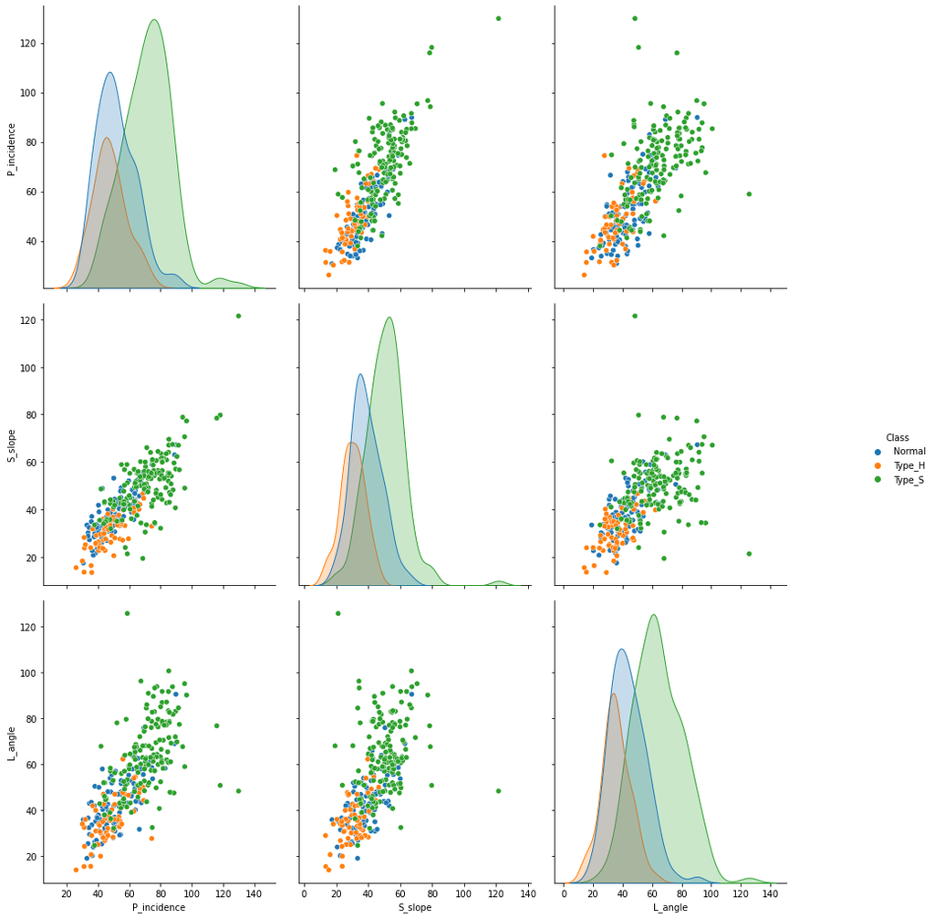

```python
# Print the pairplot for P_incidence, S_slope and L_angle features
plot_fig = sns.pairplot( Part_1_comb_df, vars = ['P_incidence', 'S_slope','L_angle'], hue='Class' )
plot_fig.fig.set_size_inches(15,15)
```

**Observations**

- The postive correlation between L_angle and S_slope is stronger across feature 'Class' of 2 types Type_H and Type_S, Normal ones are little scattered but still shows a positive correlation
- The postive correlation between P_incidence and L_angle is stronger across feature 'Class' of 3 types Type_H , Type_S and Normal.
- The postive correlation between P_incidence and S_slope is is stronger across feature 'Class' of 3 types Type_H , Type_S and Normal.

**Q 3D. Visualize a jointplot for ‘P_incidence’ and ‘S_slope’ and share insights.**

**Ans 3D.**

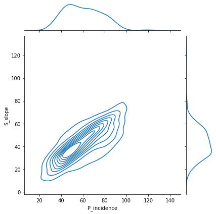

```python
# Print the joinplot to draw both bivariate and univariate KDEs:
sns.jointplot(x = "P_incidence", y = "S_slope", kind = "kde",
               data = Part_1_comb_df)
```

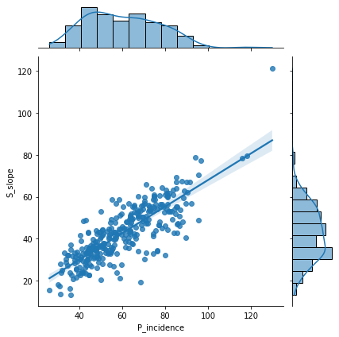

```python
# Print the joinplot to print the regression line
sns.jointplot(x = "P_incidence", y = "S_slope", kind = "reg",
               data = Part_1_comb_df)
```

**Q 3E. Visualize a boxplot to check distribution of the features and share insights.**

**Ans 3E.**

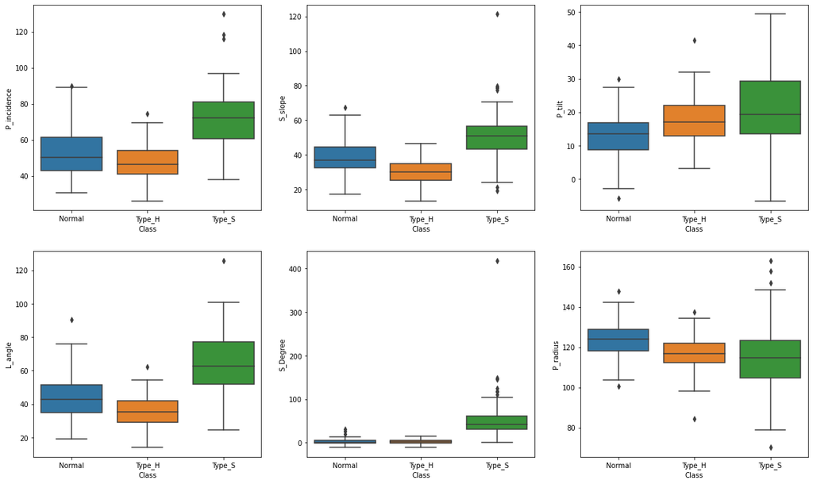

```python
#print the box plot for all each feature agaist the target 'Class' feature
# use a 2 X 3 matrix to print the box plots
plt.figure( figsize = (20,12) )
plt.subplot(2,3,1)
sns.boxplot(x ='Class', y = 'P_incidence',  data = Part_1_comb_df )
plt.subplot(2,3,2)
sns.boxplot(x ='Class', y = 'S_slope',  data = Part_1_comb_df )
plt.subplot(2,3,3)
sns.boxplot(x ='Class', y = 'P_tilt',  data = Part_1_comb_df )
plt.subplot(2,3,4)
sns.boxplot(x ='Class', y = 'L_angle',  data = Part_1_comb_df )
plt.subplot(2,3,5)
sns.boxplot(x ='Class', y = 'S_Degree',  data = Part_1_comb_df )
plt.subplot(2,3,6)
sns.boxplot(x ='Class', y = 'P_radius',  data = Part_1_comb_df )
```

**4. Model Building**

**Q 4A. Split data into X and Y**

**Ans. 4A Use the "Class" feature to group the data and split it****

```python
# import libraries to split data and train the models
from sklearn.model_selection import train_test_split
from sklearn.neighbors import KNeighborsClassifier
from scipy.stats import zscore
```

```python
# print the datatypes of the columns
Part_1_comb_df.dtypes
```

```
P_incidence    float64
P_tilt         float64
L_angle        float64
S_slope        float64
P_radius       float64
S_Degree       float64
Class           object
dtype: object
```

```python
# Declare the Class Feature as the Category variable as it has String
Part_1_comb_df['Class'] = Part_1_comb_df.Class.astype('category')
Part_1_comb_df.describe()
```

|  | P_incidence | P_tilt | L_angle | S_slope | P_radius | S_Degree |
| --- | --- | --- | --- | --- | --- | --- |
| count | 310.000000 | 310.000000 | 310.000000 | 310.000000 | 310.000000 | 310.000000 |
| mean | 60.496653 | 17.542822 | 51.930930 | 42.953831 | 117.920655 | 26.296694 |
| std | 17.236520 | 10.008330 | 18.554064 | 13.423102 | 13.317377 | 37.559027 |
| min | 26.147921 | -6.554948 | 14.000000 | 13.366931 | 70.082575 | -11.058179 |
| 25% | 46.430294 | 10.667069 | 37.000000 | 33.347122 | 110.709196 | 1.603727 |
| 50% | 58.691038 | 16.357689 | 49.562398 | 42.404912 | 118.268178 | 11.767934 |
| 75% | 72.877696 | 22.120395 | 63.000000 | 52.695888 | 125.467674 | 41.287352 |
| max | 129.834041 | 49.431864 | 125.742385 | 121.429566 | 163.071041 | 418.543082 |

```python
# Split the data into X and Y using Catrogorical varibale 'Class' as Y and rest of the columns as X
X = Part_1_comb_df.drop( labels='Class' , axis = 1 )
Y = Part_1_comb_df['Class']
```

**Q 4B. Split data into train and test with 80:20 proportion**

**Ans 4B. use the train_test_split library to split the data post level setting the data values**

```python
#To Make the columns in X comparable with each other we scale those values into z scores to unit agnostic
X_Z_Scaled = X.apply(zscore)
X_Z_Scaled.describe()
```

|  | P_incidence | P_tilt | L_angle | S_slope | P_radius | S_Degree |
| --- | --- | --- | --- | --- | --- | --- |
| count | 3.100000e+02 | 3.100000e+02 | 3.100000e+02 | 3.100000e+02 | 3.100000e+02 | 3.100000e+02 |
| mean | 1.042177e-16 | 2.096889e-16 | 1.980495e-16 | 2.829278e-17 | -5.071212e-16 | -1.277204e-16 |
| std | 1.001617e+00 | 1.001617e+00 | 1.001617e+00 | 1.001617e+00 | 1.001617e+00 | 1.001617e+00 |
| min | -1.996010e+00 | -2.411664e+00 | -2.047652e+00 | -2.207741e+00 | -3.597963e+00 | -9.961725e-01 |
| 25% | -8.173982e-01 | -6.881138e-01 | -8.060267e-01 | -7.168418e-01 | -5.423830e-01 | -6.585073e-01 |
| 50% | -1.049246e-01 | -1.186061e-01 | -1.278621e-01 | -4.095971e-02 | 2.613767e-02 | -3.874502e-01 |
| 75% | 7.194643e-01 | 4.581158e-01 | 5.975493e-01 | 7.269414e-01 | 5.676209e-01 | 3.997679e-01 |
| max | 4.029206e+00 | 3.191402e+00 | 3.984615e+00 | 5.855771e+00 | 3.395818e+00 | 1.046035e+01 |

```python
# Split X and Y into training and test set in the ratio 80:20
#x_train, x_test, y_train, y_test = train_test_split(X, Y, test_size=0.2, random_state=2)
x_train, x_test, y_train, y_test = train_test_split(X_Z_Scaled, Y, test_size=0.2, random_state=2)
```

**Q 4C Train a Supervised Learning Classification base model using KNN classifier**

**Ans 4C. Use the KNeighborsClassifier library to train the model using the training data**

```python
# Build the model and choose  points to identify the classifier and use distance as the measure to identify the classifier
# and determine the neighbour points that provides better accuracy
KNN_Classifiers = KNeighborsClassifier(n_neighbors=3, weights = 'distance')
```

```python
# Train the model with the training data
KNN_Classifiers.fit( x_train, y_train )
```

```
KNeighborsClassifier(n_neighbors=3, weights='distance')
```

**Q 4D. . Print all the possible performance metrics for both train and test data.**

```python
# Validate the trained model with the test data
y_predicted_labels = KNN_Classifiers.predict( x_test )
KNN_Classifiers.score( x_test, y_test )
```

```
0.7741935483870968
```

```python
# Other performance accuracy measures and confusion matrix
from sklearn.metrics import confusion_matrix

#Generate the confusion matrix
cf_matrix_NS = confusion_matrix(y_test, y_predicted_labels, labels=["Normal" , "Type_S" ])
cf_matrix_NH = confusion_matrix(y_test, y_predicted_labels, labels=["Normal" , "Type_H" ])
cf_matrix_HS = confusion_matrix(y_test, y_predicted_labels, labels=["Type_H" , "Type_S" ])
```

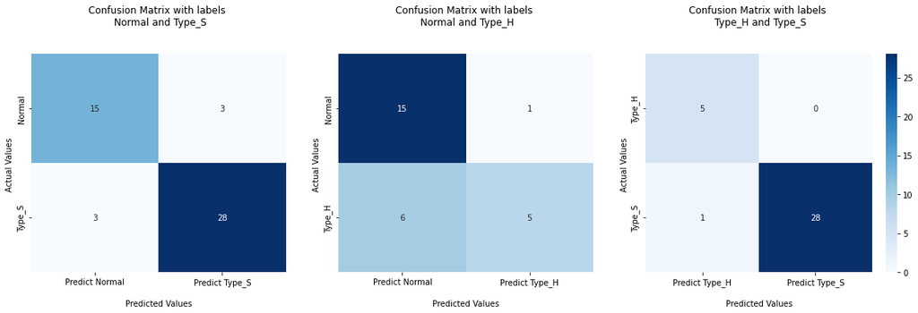

```python
mod_cm_NS = pd.DataFrame( cf_matrix_NS, index = [i for i in ['Normal', 'Type_S' ]],
                           columns = [ i for i in ['Predict Normal', 'Predict Type_S']])

mod_cm_NH = pd.DataFrame( cf_matrix_NH, index = [i for i in ['Normal', 'Type_H' ]],
                           columns = [ i for i in ['Predict Normal', 'Predict Type_H']])

mod_cm_HS = pd.DataFrame( cf_matrix_HS, index = [i for i in ['Type_H', 'Type_S' ]],
                           columns = [ i for i in ['Predict Type_H', 'Predict Type_S']])


f,(ax1,ax2,ax3) = plt.subplots(1,3,sharey=False, gridspec_kw={'width_ratios':[0.9,0.9,1]}, figsize=(20,5))
hm1 = sns.heatmap(mod_cm_NS, annot=True, cmap='Blues', cbar=False, ax=ax1)
hm1.set_title('Confusion Matrix with labels \n Normal and Type_S\n\n');
hm1.set_xlabel('\nPredicted Values')
hm1.set_ylabel('Actual Values ');


hm2 = sns.heatmap(mod_cm_NH, annot=True, cmap='Blues', cbar=False, ax=ax2)
hm2.set_title('Confusion Matrix with labels \n Normal and Type_H\n\n');
hm2.set_xlabel('\nPredicted Values')
hm2.set_ylabel('Actual Values ');


hm3 = sns.heatmap(mod_cm_HS, annot=True, cmap='Blues', ax=ax3)
hm3.set_title('Confusion Matrix with labels \n Type_H and Type_S\n\n');
hm3.set_xlabel('\nPredicted Values')
hm3.set_ylabel('Actual Values ');



## Display the visualization of the Confusion Matrix.
plt.show()
```

**Part 1 section 5. Performance Improvement**

**Q 5A. Experiment with various parameters to improve performance of the base model**

**Ans 5A**

```python
# Split the data between train and test in a 75:25 ratio
x_train1, x_test1, y_train1, y_test1 = train_test_split(X_Z_Scaled, Y, test_size=0.25, random_state=4)
KNN_Classifiers1 = KNeighborsClassifier(n_neighbors=7, weights = 'distance')
KNN_Classifiers1.fit( x_train1, y_train1 )

y_predicted_labels1 = KNN_Classifiers1.predict( x_test1 )
KNN_Classifiers1.score( x_test1, y_test1 )
```

```
0.8205128205128205
```

```python
# Split the data between train and test in a 85:15 ratio
x_train2, x_test2, y_train2, y_test2 = train_test_split(X, Y, test_size=0.15, random_state=1)
KNN_Classifiers2 = KNeighborsClassifier( n_neighbors=5 )
KNN_Classifiers2.fit( x_train2, y_train2 )

y_predicted_labels2 = KNN_Classifiers2.predict( x_test2 )
KNN_Classifiers2.score( x_test2, y_test2 )
```

```
0.851063829787234
```

```python
# Split the data between train and test in a 70:30 ratio
x_train3, x_test3, y_train3, y_test3 = train_test_split(X_Z_Scaled, Y, test_size=0.3, random_state=3)
KNN_Classifiers3 = KNeighborsClassifier( n_neighbors=7)
# algorithm ‘ball_tree’, ‘kd_tree’, ‘brute’
KNN_Classifiers3.fit( x_train3, y_train3 )

y_predicted_labels3 = KNN_Classifiers3.predict( x_test3 )
KNN_Classifiers3.score( x_test3, y_test3 )
```

```
0.7741935483870968
```

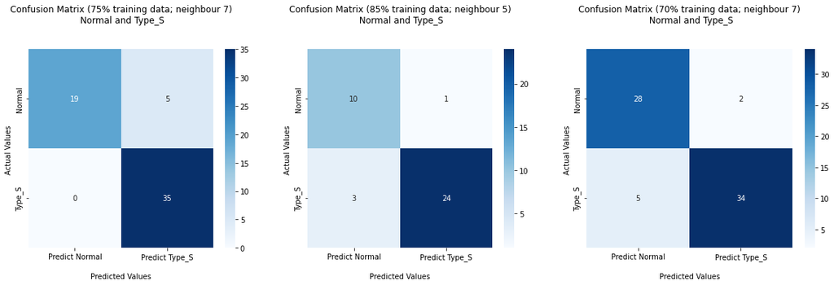

```python
# Calculate and plot the confusion matrix for three different data splits
cf_matrix_NS1 = confusion_matrix(y_test1, y_predicted_labels1, labels=["Normal" , "Type_S" ])
cf_matrix_NS2 = confusion_matrix(y_test2, y_predicted_labels2, labels=["Normal" , "Type_S" ])
cf_matrix_NS3 = confusion_matrix(y_test3, y_predicted_labels3, labels=["Normal" , "Type_S" ])

mod_cm_NS1 = pd.DataFrame( cf_matrix_NS1, index = [i for i in ['Normal', 'Type_S' ]],
                           columns = [ i for i in ['Predict Normal', 'Predict Type_S']])

mod_cm_NS2 = pd.DataFrame( cf_matrix_NS2, index = [i for i in ['Normal', 'Type_S' ]],
                           columns = [ i for i in ['Predict Normal', 'Predict Type_S']])

mod_cm_NS3 = pd.DataFrame( cf_matrix_NS3, index = [i for i in ['Normal', 'Type_S' ]],
                           columns = [ i for i in ['Predict Normal', 'Predict Type_S']])

f1,(axn1,axn2,axn3) = plt.subplots(1,3,sharey=False, gridspec_kw={'width_ratios':[0.9,0.9,1]}, figsize=(20,5))

# Configure the three heatmaps for confusion matrix
hm_m1 = sns.heatmap(mod_cm_NS1, annot=True, cmap='Blues', ax=axn1)
hm_m1.set_title('Confusion Matrix (75% training data; neighbour 7)\n Normal and Type_S\n\n');
hm_m1.set_xlabel('\nPredicted Values')
hm_m1.set_ylabel('Actual Values ');

hm_m2 = sns.heatmap(mod_cm_NS2, annot=True, cmap='Blues', ax=axn2)
hm_m2.set_title('Confusion Matrix (85% training data; neighbour 5)\n Normal and Type_S\n\n');
hm_m2.set_xlabel('\nPredicted Values')
hm_m2.set_ylabel('Actual Values ');

hm_m3 = sns.heatmap(mod_cm_NS3, annot=True, cmap='Blues', ax=axn3)
hm_m3.set_title('Confusion Matrix (70% training data; neighbour 7)\n Normal and Type_S\n\n');
hm_m3.set_xlabel('\nPredicted Values')
hm_m3.set_ylabel('Actual Values ');

plt.show()
```

```python
# Calculate the performance scores for neignbours value configured between 1 to 50 for each split data set
scores1 =[]
for k in range(1,50):
    NNH = KNeighborsClassifier(n_neighbors = k, weights = 'distance' )
    NNH.fit(x_train1, y_train1)
    scores1.append(NNH.score(x_test1, y_test1))

scores2 =[]
for k in range(1,50):
    NNH = KNeighborsClassifier(n_neighbors = k, weights = 'distance' )
    NNH.fit(x_train2, y_train2)
    scores2.append(NNH.score(x_test2, y_test2))

scores3 =[]
for k in range(1,50):
    NNH = KNeighborsClassifier(n_neighbors = k, weights = 'distance' )
    NNH.fit(x_train3, y_train3)
    scores3.append(NNH.score(x_test3, y_test3))
```

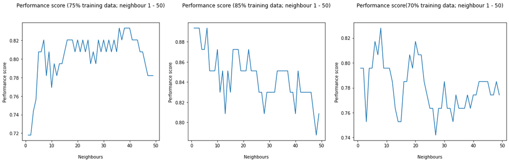

```python
# Plot the performance scores captured in the iterations using neighbour count from 1 to 50
f1, (axp1, axp2, axp3) = plt.subplots(1,3,sharey=False, gridspec_kw={'width_ratios':[0.9,0.9,1]}, figsize=(20,5))

axp1.set(xlabel='\nNeighbours', ylabel='Performance score')
axp2.set(xlabel='\nNeighbours', ylabel='Performance score')
axp3.set(xlabel='\nNeighbours', ylabel='Performance score')

axp1.set_title('Performance score (75% training data; neighbour 1 - 50)\n\n');
axp2.set_title('Performance score (85% training data; neighbour 1 - 50)\n\n');
axp3.set_title('Performance score(70% training data; neighbour 1 - 50)\n\n');

axp1.plot(range(1,50),scores1)
axp2.plot(range(1,50),scores2)
axp3.plot(range(1,50),scores3)

plt.show()
```

**Q 5B. Clearly showcase improvement in performance achieved.**

**Ans 5B.** Increasing training data improves by 10% Increasing the neighbours improves prediction precision by 10% (5 instead 6 type I and Type II errors) Increasing the training data improves prediction precision by 20% (4 instead 6 type I and Type II errors)

**Q 5C. Clearly state which parameters contributed most to improve model performance**

**Ans 5C.**

Observations

- Increasing the training data size from 80% to 85% improves the precision
- Increasing the neighbours data point from 3 to 15 does not yeild much change randing between 70 to 77%, but the neighbour count of 7 improved the accuracy above 80%
- Using the actual X split data instead of scaled (Zscore) values of X improves the accuracy by another 3%
- Changing the algorithm in KNeighborsClassifier across ‘ball_tree’, ‘kd_tree’ and ‘brute’ types does not impact the outcome
- Changing the Minkowski metric from euclidean to manhattan does not impact the outcome
- Maintaining the random split as stabtic , that assigns data set to training and test data, helps to change other parameters and evaluate the impact due to them. But if random_state parameter is not specified, that dynamically splits test data for each run, changed the accuracy in each run.

## PART B

*DOMAIN: Banking, Marketing*

*CONTEXT:* A bank X is on a massive digital transformation for all its departments. Bank has a growing customer base whee majority of them areliability customers (depositors) vs borrowers (asset customers). The bank is interested in expanding the borrowers base rapidly to bring in morebusiness via loan interests. A campaign that the bank ran in last quarter showed an average single digit conversion rate. Digital transformation being the core strength of the business strategy, marketing department wants to devise effective campaigns with better target marketing to increase the conversion ratio to double digit with same budget as per last campaign.

*PROJECT OBJECTIVE:* Build a Machine Learning model to perform focused marketing by predicting the potential customers who will convert using the historical dataset.

*1. Data Understanding and Preparation*

*Q 1A Read both the Datasets ‘Data1’ and ‘Data 2’ as DataFrame and store them into two separate variables.*

*Ans 1A.* Use the PD read_csv function to read the csv data file.

```python
# Read the data files
# Load the Data1 CSV data
part_2_Data1 = pd.read_csv( 'SupervisedLearningProject\Part2_Data1.csv' )

# Load the Data2 CSV data
part_2_Data2 = pd.read_csv( 'SupervisedLearningProject\Part2_Data2.csv' )
```

*Q 1B. Print shape and Column Names and DataTypes of both the Dataframes*

*Ans 1B.*

```python
# Print the shape of Data1 dataframe
part_2_Data1.shape
```

```
(5000, 8)
```

```python
# Print the column names and data types
part_2_Data1.dtypes
```

```
ID                       int64
Age                      int64
CustomerSince            int64
HighestSpend             int64
ZipCode                  int64
HiddenScore              int64
MonthlyAverageSpend    float64
Level                    int64
dtype: object
```

```python
# Print the shape of Data2 dataframe
part_2_Data2.shape
```

```
(5000, 7)
```

```python
# Print the column names and data types
part_2_Data2.dtypes
```

```
ID                       int64
Mortgage                 int64
Security                 int64
FixedDepositAccount      int64
InternetBanking          int64
CreditCard               int64
LoanOnCard             float64
dtype: object
```

**Q 1C. Merge both the Dataframes on ‘ID’ feature to form a single DataFrame***

*Ans 1C.* Use the dataframe merge fucntion an use the ID feature as the integrator

```python
# Merge both the Data1 and Data2 dataframes
part_2_merged_df = pd.merge( part_2_Data1, part_2_Data2, on='ID')
```

```python
# Check the size of the merged dataframe
part_2_merged_df.shape
```

```
(5000, 14)
```

```python
# List the merged column and their datatypes
part_2_merged_df.dtypes
```

```
ID                       int64
Age                      int64
CustomerSince            int64
HighestSpend             int64
ZipCode                  int64
HiddenScore              int64
MonthlyAverageSpend    float64
Level                    int64
Mortgage                 int64
Security                 int64
FixedDepositAccount      int64
InternetBanking          int64
CreditCard               int64
LoanOnCard             float64
dtype: object
```

```python
# Check for null values across the columns
part_2_merged_df.isnull().sum()
```

```
ID                      0
Age                     0
CustomerSince           0
HighestSpend            0
ZipCode                 0
HiddenScore             0
MonthlyAverageSpend     0
Level                   0
Mortgage                0
Security                0
FixedDepositAccount     0
InternetBanking         0
CreditCard              0
LoanOnCard             20
dtype: int64
```

*Q 1D. Change Datatype of below features to ‘Object’*

‘CreditCard’, ‘InternetBanking’, ‘FixedDepositAccount’, ‘Security’, ‘Level’, ‘HiddenScore’

*Ans 1D.* Change the data type as category using astype() function

```python
# Declare the 'CreditCard’, ‘InternetBanking’, ‘FixedDepositAccount’, ‘Security’, ‘Level’, ‘HiddenScore’ Feature
# as the Category variable
part_2_merged_df['CreditCard'] = part_2_merged_df.CreditCard.astype('category')
part_2_merged_df['InternetBanking'] = part_2_merged_df.InternetBanking.astype('category')
part_2_merged_df['FixedDepositAccount'] = part_2_merged_df.FixedDepositAccount.astype('category')
part_2_merged_df['Security'] = part_2_merged_df.Security.astype('category')
part_2_merged_df['Level'] = part_2_merged_df.Level.astype('category')
part_2_merged_df['HiddenScore'] = part_2_merged_df.HiddenScore.astype('category')
```

*2. . Data Exploration and Analysis:*

*Q 2A. Visualize distribution of Target variable ‘LoanOnCard’ and clearly share insights.*

*Ans 2A.* Use the values of feature 'LoanOnCard' to publish the distribution

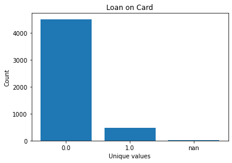

```python
#Store the unique values and its count in a series.  Include null/nan values count too
loc_ser = part_2_merged_df.LoanOnCard.value_counts(dropna=False)

#Store the index values ,  actual unique values in a list to use as X axis values
x_val = pd.Series(loc_ser.index, dtype=str)

#Store the count values in a list to display in Y axis
y_val = loc_ser.tolist()

#Plot the bar chart
plt.bar(x_val, y_val)

#Set the Title and axis sub titles
plt.title('Loan on Card')
plt.xlabel('Unique values')
plt.ylabel('Count')
```

Observations on 'LoanOnCard' feature

- 90% of the rows of the feature has a value is 0
- 9.6% of the rows of the feature has a value 1
- 0.4% of the rows of the feature has no value

*Q 2B. Check the percentage of missing values and impute if required*

***Ans 2B.

```python
#Print the Loanoncard feature values and count
loc_ser
```

```
0.0    4500
1.0     480
NaN      20
Name: LoanOnCard, dtype: int64
```

Loanoncard feature has 20 missing or null values out of total rows.

```python
# Calculate and print the count and % of null/missing values
print(color.BOLD +'Answer 2B '+color.END+':The Loandoncard has {} missing values which is {:.2f}% of total {} rows '.format(y_val[2], y_val[2]*100/part_2_merged_df.shape[0], part_2_merged_df.shape[0]))
```

```
Answer 2B :The Loandoncard has 20 missing values which is 0.40% of total 5000 rows
```

Since most of the column values has 0 we can impute the missing values with 0 value

```python
#Use the fillna method to fill value 0 for the missing row value
part_2_merged_df['LoanOnCard'] = part_2_merged_df['LoanOnCard'].fillna(0)

#Check if the value is filled by pritning the count including nan values
part_2_merged_df.LoanOnCard.value_counts(dropna=False)
```

```
0.0    4520
1.0     480
Name: LoanOnCard, dtype: int64
```

*Ans 2B.* All the missing row value of feature 'LoanOnCard' is filled with 0

*Q 2C. Check for unexpected values in each categorical variable and impute with best suitable value.*

*Ans 2C.* Check each Categorical feature and list the unique values and find the odd ones Category features are 'CreditCard’, ‘InternetBanking’, ‘FixedDepositAccount’, ‘Security’, ‘Level’, ‘HiddenScore’

```python
# Check the values for 'CreditCard' feature
part_2_merged_df.CreditCard.value_counts(dropna=False)
```

```
0    3530
1    1470
Name: CreditCard, dtype: int64
```

```python
print('There are no unexpected values in the CreditCard feature')
```

```
There are no unexpected values in the CreditCard feature
```

```python
# Check the values for 'InternetBanking' feature
part_2_merged_df.InternetBanking.value_counts(dropna=False)
```

```
1    2984
0    2016
Name: InternetBanking, dtype: int64
```

```python
print('There are no unexpected values in the InternetBanking feature')
```

```
There are no unexpected values in the InternetBanking feature
```

```python
# Check the values for 'FixedDepositAccount' feature
part_2_merged_df.FixedDepositAccount.value_counts(dropna=False)
```

```
0    4698
1     302
Name: FixedDepositAccount, dtype: int64
```

```python
print('There are no unexpected values in the FixedDepositAccount feature')
```

```
There are no unexpected values in the FixedDepositAccount feature
```

```python
# Check the values for 'Security' feature
part_2_merged_df.Security.value_counts(dropna=False)
```

```
0    4478
1     522
Name: Security, dtype: int64
```

```python
print('There are no unexpected values in the Security feature')
```

```
There are no unexpected values in the Security feature
```

```python
# Check the values for 'Level' feature
part_2_merged_df.Level.value_counts(dropna=False)
```

```
1    2096
3    1501
2    1403
Name: Level, dtype: int64
```

```python
print('There are no unexpected values in the Level feature')
```

```
There are no unexpected values in the Level feature
```

```python
# Check the values for 'HiddenScore' feature
part_2_merged_df.HiddenScore.value_counts(dropna=False)
```

```
1    1472
2    1296
4    1222
3    1010
Name: HiddenScore, dtype: int64
```

```python
print('There are no unexpected values in the HiddenScore feature')
```

```
There are no unexpected values in the HiddenScore feature
```

*Ans 2C.* There are no unexpected values in any of the Categorical features

**3. Data Preparation and model building:**

*Q 3A. Split data into X and Y*

*Ans 3A*

```python
# Split the data into X and Y using Catrogorical varibale 'LoanonCard' as Y and rest of the columns as X

X2     = part_2_merged_df.drop( labels=['ID', 'ZipCode', 'LoanOnCard'] , axis = 1 )
Y2_LOC = part_2_merged_df['LoanOnCard']
```

*Q 3B. Split data into train and test. Keep 25% data reserved for testing*

*Ans. 3B.*

```python
x2_train, x2_test, y2_train, y2_test = train_test_split(X2, Y2_LOC, test_size=0.25, random_state=2)
```

*Q 3C.Train a Supervised Learning Classification base model - Logistic Regression.*

*Ans 3C.*

```python
from sklearn.linear_model import LogisticRegression
from sklearn.metrics import accuracy_score

#Build the logistic regression model
log_reg = LogisticRegression(max_iter=4000)

log_reg.fit(x2_train, y2_train.values.ravel())
```

```
LogisticRegression(max_iter=4000)
```

```python
pred_test = log_reg.predict(x2_test)
```

```python
pred_train = log_reg.predict(x2_train)
```

```python
test_accuracy=accuracy_score(y2_test, pred_test)

print('Test Accuracy: ',np.round(test_accuracy,2))
```

```
Test Accuracy:  0.94
```

```
confusion matrix_train_data =
 [[3332   54]
 [ 129  235]]
```

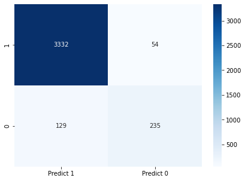

```python
from sklearn.metrics import classification_report,confusion_matrix

# Print the confusion matrix for the logistic regression for training data
mat_train = confusion_matrix(y2_train,pred_train)

print("confusion matrix_train_data = \n",mat_train)
log_cm_train = pd.DataFrame(mat_train, index = [i for i in ["1","0"]],
                  columns = [i for i in ["Predict 1","Predict 0"]])
plt.figure(figsize = (7,5))
sns.heatmap(log_cm_train, annot=True, fmt='d', cmap='Blues')
```

```
confusion matrix_test_data =
 [[1116   18]
 [  52   64]]
```

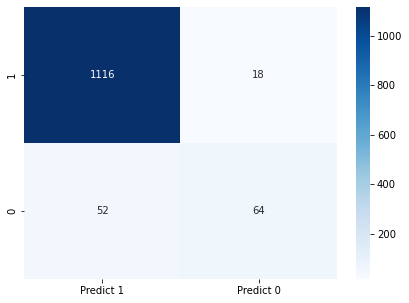

```python
# Print the confusion matrix for the logistic regression for test data
mat_test = confusion_matrix(y2_test,pred_test)
print("confusion matrix_test_data = \n",mat_test)

log_cm_test = pd.DataFrame(mat_test, index = [i for i in ["1","0"]],
                  columns = [i for i in ["Predict 1","Predict 0"]])
plt.figure(figsize = (7,5))
sns.heatmap(log_cm_test, annot=True, fmt='d', cmap='Blues')
```

The confusion matrix

False Positives (FP): incorrectly predicted that they have loan on card (a "Type I error") 18 Falsely predict positive Type I error

False Negatives (FN): incorrectly predicted that they don't have loan on card (a "Type II error") 52 Falsely predict negative Type II error

*Q 3D. Print evaluation metrics for the model and clearly share insights.*

*Ans 3D.*

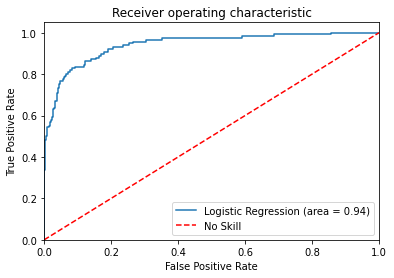

```python
#AUC ROC curve
from sklearn.metrics import roc_auc_score
from sklearn.metrics import roc_curve

# Print the ROC AUC curve
logit_roc_auc = roc_auc_score(y2_test, log_reg.predict_proba(x2_test)[:,1])
fpr, tpr, thresholds = roc_curve(y2_test, log_reg.predict_proba(x2_test)[:,1])
plt.figure()
plt.plot(fpr, tpr, label='Logistic Regression (area = %0.2f)' % logit_roc_auc)
plt.plot([0, 1], [0, 1],'r--',label='No Skill')
plt.xlim([0.0, 1.0])
plt.ylim([0.0, 1.05])
plt.xlabel('False Positive Rate')
plt.ylabel('True Positive Rate')
plt.title('Receiver operating characteristic')
plt.legend(loc="lower right")
plt.savefig('Log_ROC')
plt.show()
```

```
Best Threshold=0.089113, G-Mean=0.872
```

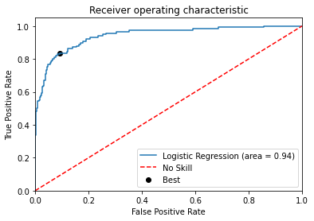

```python
# roc curve for logistic regression model with optimal threshold
from numpy import sqrt
from numpy import argmax

# Print the ROC AUC curve
logit_roc_auc = roc_auc_score(y2_test, log_reg.predict_proba(x2_test)[:,1])
fpr, tpr, thresholds = roc_curve(y2_test, log_reg.predict_proba(x2_test)[:,1])
# calculate the g-mean for each threshold
gmeans = sqrt(tpr * (1-fpr))
# locate the index of the largest g-mean
ix = argmax(gmeans)
print('Best Threshold=%f, G-Mean=%.3f' % (thresholds[ix], gmeans[ix]))
plt.figure()
plt.plot(fpr, tpr, label='Logistic Regression (area = %0.2f)' % logit_roc_auc)
plt.plot([0, 1], [0, 1],'r--',label='No Skill')
plt.scatter(fpr[ix], tpr[ix], marker='o', color='black', label='Best')
plt.xlim([0.0, 1.0])
plt.ylim([0.0, 1.05])
plt.xlabel('False Positive Rate')
plt.ylabel('True Positive Rate')
plt.title('Receiver operating characteristic')
plt.legend(loc="lower right")
plt.savefig('Log_ROC')
plt.show()
```

```
Best Threshold=0.230948, F-Score=0.688
```

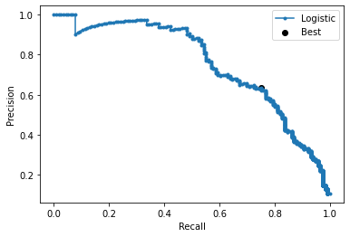

```python
from sklearn.metrics import precision_recall_curve
yhat=log_reg.predict_proba(x2_test)[:,1]
# calculate roc curves
precision, recall, thresholds = precision_recall_curve(y2_test, yhat)
# convert to f score
fscore = (2 * precision * recall) / (precision + recall)
# locate the index of the largest f score
ix = argmax(fscore)
print('Best Threshold=%f, F-Score=%.3f' % (thresholds[ix], fscore[ix]))
# plot the roc curve for the model
# no_skill = len(y_test[y_test==1]) / len(y_test)
# plt.plot([0,1], [no_skill,no_skill], linestyle='--', label='No Skill')
plt.plot(recall, precision, marker='.', label='Logistic')
plt.scatter(recall[ix], precision[ix], marker='o', color='black', label='Best')
# axis labels
plt.xlabel('Recall')
plt.ylabel('Precision')
plt.legend()
# show the plot
plt.show()
```

**Ans 3D. Observations**

- The accuracy score is 0.94 - 94%
- The ROC curve area is close the left top corner inicating the model is well trained
- The ROC Area under curve is 0.94 which is close to 1 is a good indicator on Sensitivity is higher. or good True Postivity rate.
- The F-score of 0.688 above 0.5 indicates well above average score

**Q 3E. Balance the data using the right balancing technique.**

*Ans 3E* Currently the LoanOnCard feature has 90:10 ratio of distribution of values 0.0 and 1.0 To Balance the data convert 40% of the 0.0 values to 1.0 Perform some analysis to find a pattern or convert the top 2000 rows , LoanOnCard feature values

```python
# Check the count of the unique values
part_2_merged_df['LoanOnCard'].value_counts()
```

```
0.0    4520
1.0     480
Name: LoanOnCard, dtype: int64
```

```python
part_2_merged_df.head()
```

|  | ID | Age | CustomerSince | HighestSpend | ZipCode | HiddenScore | MonthlyAverageSpend | Level | Mortgage | Security | FixedDepositAccount | InternetBanking | CreditCard | LoanOnCard |
| --- | --- | --- | --- | --- | --- | --- | --- | --- | --- | --- | --- | --- | --- | --- |
| 0 | 1 | 25 | 1 | 49 | 91107 | 4 | 1.6 | 1 | 0 | 1 | 0 | 0 | 0 | 0.0 |
| 1 | 2 | 45 | 19 | 34 | 90089 | 3 | 1.5 | 1 | 0 | 1 | 0 | 0 | 0 | 0.0 |
| 2 | 3 | 39 | 15 | 11 | 94720 | 1 | 1.0 | 1 | 0 | 0 | 0 | 0 | 0 | 0.0 |
| 3 | 4 | 35 | 9 | 100 | 94112 | 1 | 2.7 | 2 | 0 | 0 | 0 | 0 | 0 | 0.0 |
| 4 | 5 | 35 | 8 | 45 | 91330 | 4 | 1.0 | 2 | 0 | 0 | 0 | 0 | 1 | 0.0 |

```python
# Calculate the correlation between the features and print as heatmap to understand the relationship
correlation_data1 = part_2_merged_df.corr()
correlation_data1.style.background_gradient(cmap='PuBu')
```

|  | ID | Age | CustomerSince | HighestSpend | ZipCode | MonthlyAverageSpend | Mortgage | LoanOnCard |
| --- | --- | --- | --- | --- | --- | --- | --- | --- |
| ID | 1.000000 | -0.008473 | -0.008326 | -0.017695 | 0.013432 | -0.024675 | -0.013920 | -0.024801 |
| Age | -0.008473 | 1.000000 | 0.994215 | -0.055269 | -0.029216 | -0.052012 | -0.012539 | -0.007726 |
| CustomerSince | -0.008326 | 0.994215 | 1.000000 | -0.046574 | -0.028626 | -0.050077 | -0.010582 | -0.007413 |
| HighestSpend | -0.017695 | -0.055269 | -0.046574 | 1.000000 | -0.016410 | 0.645984 | 0.206806 | 0.502462 |
| ZipCode | 0.013432 | -0.029216 | -0.028626 | -0.016410 | 1.000000 | -0.004061 | 0.007383 | 0.000107 |
| MonthlyAverageSpend | -0.024675 | -0.052012 | -0.050077 | 0.645984 | -0.004061 | 1.000000 | 0.109905 | 0.366889 |
| Mortgage | -0.013920 | -0.012539 | -0.010582 | 0.206806 | 0.007383 | 0.109905 | 1.000000 | 0.142095 |
| LoanOnCard | -0.024801 | -0.007726 | -0.007413 | 0.502462 | 0.000107 | 0.366889 | 0.142095 | 1.000000 |

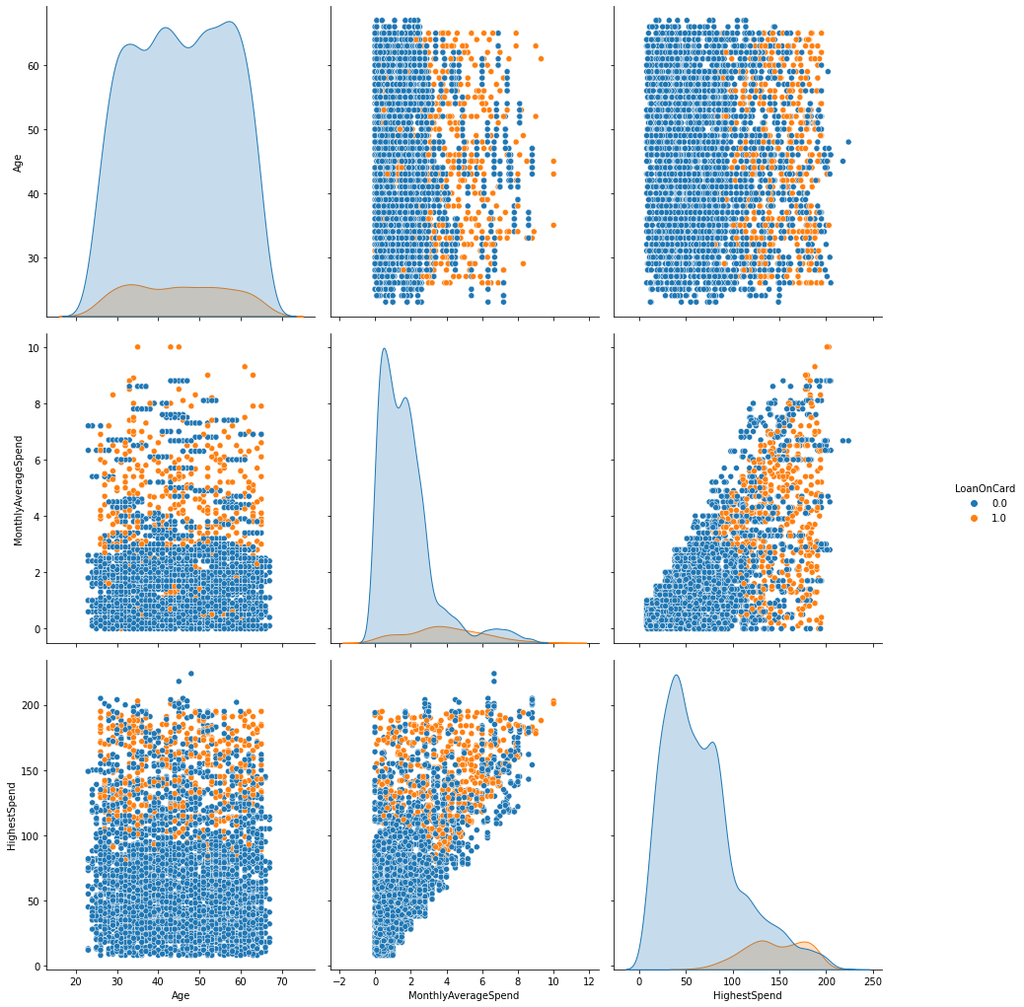

```python
# Use the pairplot to arrive at the boundries of correlated data to balance the 'LoanOnCard' feature
plot_fig1 = sns.pairplot( part_2_merged_df, vars = ['Age', 'MonthlyAverageSpend','HighestSpend'], hue='LoanOnCard' )
plot_fig1.fig.set_size_inches(15,15)
```

```python
row_count = 0
proc_count = 0

# Create a copy of the orginal merged dataframe to balance
part2_bal_df = part_2_merged_df.copy(deep=True)

# Balance the LoanOnCard on card so that unique values are in equal proportion
# Use the MonthlyAverageSpend and HighestSpend values from the pair plot correlation
for index, row in part2_bal_df.iterrows():
    proc_count = proc_count + 1
    if (row['LoanOnCard'] == 0.0) & (row['MonthlyAverageSpend'] > 1.35) & (row['HighestSpend'] > 36):
        part2_bal_df.at[index,'LoanOnCard'] = 1.0
        row_count = row_count + 1
    if row_count > 2249:
        break
```

```python
# Check the balanced data count post balancing
part2_bal_df['LoanOnCard'].value_counts()
```

```
1.0    2704
0.0    2296
Name: LoanOnCard, dtype: int64
```

**Q 3F. Again train the same previous model on balanced data***

**Ans 3F.**

```python
# Distribute the features agaisnt  the x axis and y axis
X3     = part2_bal_df.drop( labels=['ID', 'ZipCode', 'LoanOnCard'] , axis = 1 )
Y3_LOC = part2_bal_df['LoanOnCard']
```

```python
# Split the data post balancing the 'LoanOnCard' feature
x3_train, x3_test, y3_train, y3_test = train_test_split(X3, Y3_LOC, test_size=0.25, random_state=4)
```

```python
#Build the logistic regression model
log_reg1 = LogisticRegression(max_iter=1000)

log_reg1.fit(x3_train, y3_train.values.ravel())
```

```
LogisticRegression(max_iter=1000)
```

```python
pred_test1 = log_reg1.predict(x3_test)
```

```python
pred_train1 = log_reg1.predict(x3_train)
```

```python
# Print the test accuracy score of the trained model against the test data
test_accuracy1=accuracy_score( y3_test, pred_test1 )

print('Test Accuracy: ',np.round(test_accuracy1,2))
```

```
Test Accuracy:  0.96
```

**Evaluation Metrics**

The following evaluation metrics are to be used to gauge the model performance

1. Confusion Matrix
2. ROC Curve
3. F-Score

```
confusion matrix_train_data =
 [[1625   79]
 [  83 1963]]
```

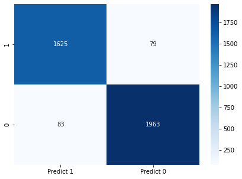

```python
# Confusion Matrix for balanced training data
mat_train2 = confusion_matrix( pred_train1, y3_train )

print("confusion matrix_train_data = \n",mat_train2)
log_cm_train2 = pd.DataFrame(mat_train2, index = [i for i in ["1","0"]],
                  columns = [i for i in ["Predict 1","Predict 0"]])
plt.figure(figsize = (7,5))
sns.heatmap(log_cm_train2, annot=True, fmt='d', cmap='Blues')
```

```
confusion matrix_test_data =
 [[562  20]
 [ 26 642]]
```

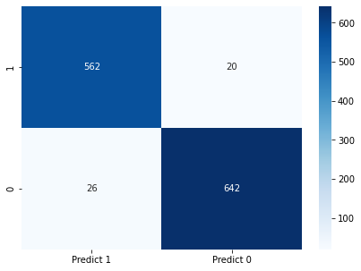

```python
# Confusion Matrix for balanced test data
mat_test2 = confusion_matrix(pred_test1, y3_test)
print("confusion matrix_test_data = \n",mat_test2)

log_cm_test1 = pd.DataFrame(mat_test2, index = [i for i in ["1","0"]],
                  columns = [i for i in ["Predict 1","Predict 0"]])
plt.figure(figsize = (7,5))
sns.heatmap(log_cm_test1, annot=True, fmt='d', cmap='Blues')
```

The confusion matrix

False Positives (FP): incorrectly predicted that they have loan on card (a "Type I error") 26 Falsely predict positive Type I error

False Negatives (FN): incorrectly predicted that they don't have loan on card (a "Type II error") 20 Falsely predict negative Type II error

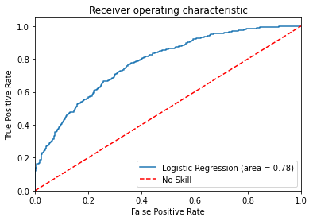

```python
#AUC ROC curve for balanced data
from sklearn.metrics import roc_auc_score
from sklearn.metrics import roc_curve

logit_roc_auc1 = roc_auc_score(y3_test, log_reg.predict_proba(x3_test)[:,1])
fpr, tpr, thresholds = roc_curve(y3_test, log_reg.predict_proba(x3_test)[:,1])
plt.figure()
plt.plot(fpr, tpr, label='Logistic Regression (area = %0.2f)' % logit_roc_auc1)
plt.plot([0, 1], [0, 1],'r--',label='No Skill')
plt.xlim([0.0, 1.0])
plt.ylim([0.0, 1.05])
plt.xlabel('False Positive Rate')
plt.ylabel('True Positive Rate')
plt.title('Receiver operating characteristic')
plt.legend(loc="lower right")
plt.savefig('Log_ROC')
plt.show()
```

```
Best Threshold=0.003199, G-Mean=0.706
```

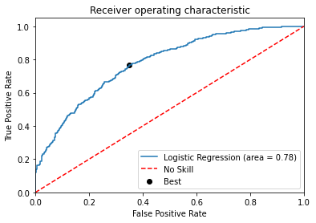

```python
# roc curve for logistic regression model with optimal threshold
from numpy import sqrt
from numpy import argmax

logit_roc_auc1 = roc_auc_score(y3_test, log_reg.predict_proba(x3_test)[:,1])
fpr, tpr, thresholds = roc_curve(y3_test, log_reg.predict_proba(x3_test)[:,1])
# calculate the g-mean for each threshold
gmeans = sqrt(tpr * (1-fpr))
# locate the index of the largest g-mean
ix = argmax(gmeans)
print('Best Threshold=%f, G-Mean=%.3f' % (thresholds[ix], gmeans[ix]))
plt.figure()
plt.plot(fpr, tpr, label='Logistic Regression (area = %0.2f)' % logit_roc_auc1)
plt.plot([0, 1], [0, 1],'r--',label='No Skill')
plt.scatter(fpr[ix], tpr[ix], marker='o', color='black', label='Best')
plt.xlim([0.0, 1.0])
plt.ylim([0.0, 1.05])
plt.xlabel('False Positive Rate')
plt.ylabel('True Positive Rate')
plt.title('Receiver operating characteristic')
plt.legend(loc="lower right")
plt.savefig('Log_ROC')
plt.show()
```

```
Best Threshold=0.000743, F-Score=0.752
```

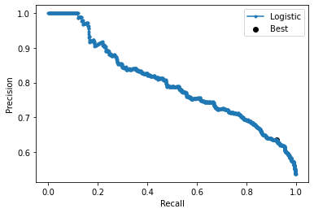

```python
# F-score calculation for balanced data
yhat=log_reg.predict_proba(x3_test)[:,1]
# calculate roc curves
precision, recall, thresholds = precision_recall_curve(y3_test, yhat)
# convert to f score
fscore = (2 * precision * recall) / (precision + recall)
# locate the index of the largest f score
ix = argmax(fscore)
print('Best Threshold=%f, F-Score=%.3f' % (thresholds[ix], fscore[ix]))
# plot the roc curve for the model
# no_skill = len(y_test[y_test==1]) / len(y_test)
# plt.plot([0,1], [no_skill,no_skill], linestyle='--', label='No Skill')
plt.plot(recall, precision, marker='.', label='Logistic')
plt.scatter(recall[ix], precision[ix], marker='o', color='black', label='Best')
# axis labels
plt.xlabel('Recall')
plt.ylabel('Precision')
plt.legend()
# show the plot
plt.show()
```

**Ans 3F. Observations**

*Comparision*

-The Accuracy of balanced model has improved 2% over the old model.

-The True Postivity rate or Prediction of positive and negative over actual has improved by 1.69% in balanced model

*4. Performance Improvement*

*Q 4A. . Train a base model each for SVM, KNN*

*Ans 4A. Build and train a SVM model*

```python
from sklearn.svm import SVC

# Building a Support Vector Machine on train data
svc_model = SVC(C= .1, kernel='linear', gamma= 1, random_state=1)
svc_model.fit(x3_train, y3_train)

prediction = svc_model .predict(x3_test)
```

```python
# check the accuracy on the training set
print(svc_model.score(x3_train, y3_train))
print(svc_model.score(x3_test, y3_test))
```

```
0.9552
0.9608
```

```python
# Calculate the confusion matrix for the SVM trainded model on test data score
print("Confusion Matrix:\n",confusion_matrix(prediction,y3_test))
```

```
Confusion Matrix:
 [[558  19]
 [ 30 643]]
```

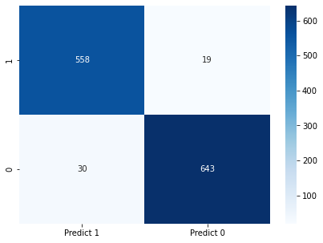

```python
# Print the confusion matrix for the SVM trainded model on test data score
cm_svm = confusion_matrix( prediction, y3_test )

df_cm_svm = pd.DataFrame(cm_svm, index = [i for i in ["1","0"]],
                  columns = [i for i in ["Predict 1","Predict 0"]])
plt.figure(figsize = (7,5))
sns.heatmap(df_cm_svm, annot=True, fmt='d' , cmap='Blues' )
```

*Build a KNN model*

```python
KNN_Classifiers_4 = KNeighborsClassifier(n_neighbors=3, weights = 'distance')
```

```python
# Drop all the cateogoryical value to calculate zscore
X3_KNN2 = part2_bal_df.drop( labels=['ID', 'ZipCode', 'CreditCard', 'InternetBanking', 'FixedDepositAccount', 'Security', 'Level', 'HiddenScore', 'LoanOnCard'] , axis = 1 )
Y3_KNN2 = part2_bal_df['LoanOnCard']

XScaled_KNN  = X3_KNN2.apply(zscore)  # convert all attributes to Z scale

XScaled_KNN.describe()
```

|  | Age | CustomerSince | HighestSpend | MonthlyAverageSpend | Mortgage |
| --- | --- | --- | --- | --- | --- |
| count | 5.000000e+03 | 5.000000e+03 | 5.000000e+03 | 5.000000e+03 | 5.000000e+03 |
| mean | 2.478018e-17 | -1.693312e-16 | 1.939449e-16 | -2.078338e-17 | 2.810197e-16 |
| std | 1.000100e+00 | 1.000100e+00 | 1.000100e+00 | 1.000100e+00 | 1.000100e+00 |
| min | -1.948906e+00 | -2.014911e+00 | -1.428969e+00 | -1.108987e+00 | -5.555239e-01 |
| 25% | -9.019702e-01 | -8.812043e-01 | -7.554825e-01 | -7.084116e-01 | -5.555239e-01 |
| 50% | -2.952359e-02 | -9.121982e-03 | -2.123482e-01 | -2.506106e-01 | -5.555239e-01 |
| 75% | 8.429230e-01 | 8.629604e-01 | 5.263146e-01 | 3.216407e-01 | 4.375576e-01 |
| max | 1.889859e+00 | 1.996667e+00 | 3.263712e+00 | 4.613525e+00 | 5.688108e+00 |

```python
# Split X and y into training and test set in 75:25 ratio

Xknn_train, Xknn_test, yknn_train, yknn_test = train_test_split(XScaled_KNN, Y3_KNN2, test_size=0.25, random_state=3)
```

```python
# Train the model with split data of zscores
KNN_Classifiers_4.fit(Xknn_train, yknn_train)
```

```
KNeighborsClassifier(n_neighbors=3, weights='distance')
```

```python
predicted_labels_knn = KNN_Classifiers_4.predict(Xknn_test)
KNN_Classifiers_4.score(Xknn_test, yknn_test)
```

```
0.9624
```

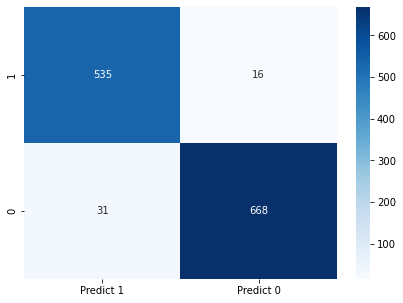

```python
# Calculate and print the confusion matrix for the KNN trainded model on test data score
cm_knn = confusion_matrix( predicted_labels_knn, yknn_test)

df_cm_knn = pd.DataFrame(cm_knn, index = [i for i in ["1","0"]],
                  columns = [i for i in ["Predict 1","Predict 0"]])
plt.figure(figsize = (7,5))
sns.heatmap(df_cm_knn, annot=True, fmt='d' , cmap='Blues' )
```

*Q 4B . Tune parameters for each of the models wherever required and finalize a model.*

*Ans 4B.* Tune the parameters for SVM model by changing the C value, 'Gamma' value and change the 'Kernel' type

```python
# Building a Support Vector Machine trainng model on train data and use Kernel type 'rbf'
svc_model_itr = SVC( kernel='rbf', random_state=1)
svc_model_itr.fit(x3_train, y3_train)

prediction_itr = svc_model_itr.predict(x3_test)
print(svc_model_itr.score(x3_train, y3_train))
print(svc_model_itr.score(x3_test, y3_test))
```

```
0.7856
0.7744
```

```python
# Building a Support Vector Machine trainng model on train data and use Kernel type 'poly'
svc_model_itr = SVC( kernel='poly', random_state=1 )
svc_model_itr.fit(x3_train, y3_train)

prediction_itr = svc_model_itr.predict(x3_test)
print(svc_model_itr.score(x3_train, y3_train))
print(svc_model_itr.score(x3_test, y3_test))
```

```
0.76
0.7448
```

```python
# Building a Support Vector Machine trainng model on train data and use Kernel type 'sigmoid'
svc_model_itr = SVC( kernel='sigmoid', random_state=1 )
svc_model_itr.fit(x3_train, y3_train)

prediction_itr = svc_model_itr.predict(x3_test)
print(svc_model_itr.score(x3_train, y3_train))
print(svc_model_itr.score(x3_test, y3_test))
```

```
0.6136
0.5936
```

```python
# Using 'Linear' Kernel as the other kernels has lesser accuracy
C_Val_List = [0.01, 0.1, 0.5, 1.0, 10.0, 100.0]
Score_Itr = []

for i in C_Val_List:
    print(i)
    svc_model_itr = SVC(C= i, kernel='linear', gamma= 1, random_state=1)
    svc_model_itr.fit(x3_train, y3_train)
    prediction_itr = svc_model_itr.predict(x3_test)
    Score_Itr.append(svc_model_itr.score(x3_test, y3_test))

print("Iteration Completed")
```

```
0.01
0.1
0.5
1.0
10.0
100.0
Iteration Completed
```

*Ans 4B contd.. Tune the parameters Neighbours in the KNN model*

```python
# Iterate the KNN model agaist 3 data split at 80%, 75% and 70% varying the neignbour count between 1 to 50
Xknn1_train, Xknn1_test, yknn1_train, yknn1_test = train_test_split(XScaled_KNN, Y3_KNN2, test_size=0.20, random_state=1)
Xknn2_train, Xknn2_test, yknn2_train, yknn2_test = train_test_split(XScaled_KNN, Y3_KNN2, test_size=0.25, random_state=2)
Xknn3_train, Xknn3_test, yknn3_train, yknn3_test = train_test_split(XScaled_KNN, Y3_KNN2, test_size=0.30, random_state=4)

scores1 =[]
for k in range(1,50):
    NNH = KNeighborsClassifier(n_neighbors = k, weights = 'distance' )
    NNH.fit(Xknn1_train, yknn1_train)
    scores1.append(NNH.score(Xknn1_test, yknn1_test))

scores2 =[]
for k in range(1,50):
    NNH = KNeighborsClassifier(n_neighbors = k, weights = 'distance' )
    NNH.fit(Xknn2_train, yknn2_train)
    scores2.append(NNH.score(Xknn2_test, yknn2_test))

scores3 =[]
for k in range(1,50):
    NNH = KNeighborsClassifier(n_neighbors = k, weights = 'distance' )
    NNH.fit(Xknn3_train, yknn3_train)
    scores3.append(NNH.score(Xknn3_test, yknn3_test))
```

*Q 4C Print evaluation metrics for final model.*

*Ans 4C*

```python
print ("{:<8} {:<15}".format('C-Value','Score'))

for (i,j) in zip(C_Val_List, Score_Itr):
    print ("{:<8} {:<15}".format( i, j))
```

```
C-Value  Score
0.01     0.9536
0.1      0.9608
0.5      0.964
1.0      0.964
10.0     0.964
100.0    0.9656
```

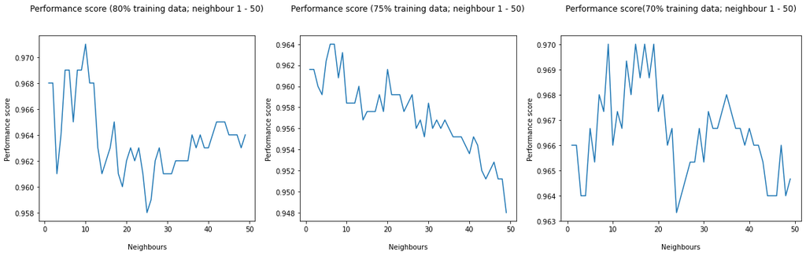

```python
# Print the scores agaisnt the neighbour counts
f1, (axp1, axp2, axp3) = plt.subplots(1,3,sharey=False, gridspec_kw={'width_ratios':[0.9,0.9,1]}, figsize=(20,5))

axp1.set(xlabel='\nNeighbours', ylabel='Performance score')
axp2.set(xlabel='\nNeighbours', ylabel='Performance score')
axp3.set(xlabel='\nNeighbours', ylabel='Performance score')

axp1.set_title('Performance score (80% training data; neighbour 1 - 50)\n\n');
axp2.set_title('Performance score (75% training data; neighbour 1 - 50)\n\n');
axp3.set_title('Performance score(70% training data; neighbour 1 - 50)\n\n');

axp1.plot(range(1,50),scores1)
axp2.plot(range(1,50),scores2)
axp3.plot(range(1,50),scores3)

plt.show()
```

```python
# Print the Max values of scores and its  neighbour count

print("{:<10} {:<15} {:<10}".format('Training_Data','Neighbour', 'Max Performance Score'))
print("{:<13} {:<15} {:<15}".format('80%',scores1.index(max(scores1)), max(scores1)))
print("{:<13} {:<15} {:<32}".format('75%',scores2.index(max(scores2)), max(scores2)))
print("{:<13} {:<15} {:<32}".format('70%',scores3.index(max(scores3)), max(scores3)))
```

```
Training_Data Neighbour       Max Performance Score
80%           9               0.971
75%           5               0.964
70%           8               0.97
```

*Q 4D. Share improvement achieved from base model to final model.*

*Ans 4D*

**Improvements achieved**

- Accuracy / Score
1. Logistic Regression : 96%
2. SVM model : 96%
3. KNN Model : 97%

All the three models are close to 96-97% where as the KNN provides the higher value conpared to the three

> Iterating the final model using varying hyperparameters yealds less significant improvement.